# Univariate: DARWIN

Jose Tamez

2023-02-07

# 1 DARWIN Univariate

### 1.0.1 Loading the libraries

```r
library("FRESA.CAD")
library(readxl)
op <- par(no.readonly = TRUE)
pander::panderOptions('digits', 3)
pander::panderOptions('table.split.table', 400)
pander::panderOptions('keep.trailing.zeros',TRUE)
```

## 1.1 The Data

```r
DARWIN <- read.csv("~/GitHub/FCA/Data/DARWIN/DARWIN.csv")
rownames(DARWIN) <- DARWIN$ID
DARWIN$ID <- NULL
DARWIN$class <- 1*(DARWIN$class=="P")
print(table(DARWIN$class))
```

```
#>
#>  0  1
#> 85 89
```

```r
DARWIN[,1:ncol(DARWIN)] <- sapply(DARWIN,as.numeric)

signedlog <- function(x) { return (sign(x)*log(abs(1.0e12*x)+1.0))}
whof <- !(colnames(DARWIN) %in% c("class"));
DARWIN[,whof] <- signedlog(DARWIN[,whof])
```

#### 1.1.0.1 Standarize the names for the reporting

```r
dataframe <- DARWIN
outcome <- "class"
```

```r
pander::pander(c(rows=nrow(dataframe),col=ncol(dataframe)-1))
```

| rows | col |
| --- | --- |
| 174 | 450 |

```r
pander::pander(table(dataframe[,outcome]))
```

| 0 | 1 |
| --- | --- |
| 85 | 89 |

```r
varlist <- colnames(dataframe)
varlist <- varlist[varlist != outcome]
varlist <- as.data.frame(cbind(name=varlist,desc=varlist))
```

## 1.2 Univariate

```r
univariate_columns <- c("caseMean","caseStd","controlMean","controlStd","controlKSP","ROCAUC","WilcoxRes.p","FRes.p")
univar <- uniRankVar(varlist,
               paste(outcome,"~1"),
               outcome,
               dataframe,
               categorizationType = "Raw",
               type = "LOGIT",
               rankingTest = "AUC",
                cateGroups = c(0.1, 0.9),
                raw.dataFrame = NULL,
                description = ".",
                uniType = "Binary")
```

100 : mean_jerk_in_air6 200 : disp_index12 300 : mean_speed_in_air17 400 : gmrt_on_paper23

```r
pander::pander(univar$orderframe[1:20,univariate_columns])
```

|  | caseMean | caseStd | controlMean | controlStd | controlKSP | ROCAUC | WilcoxRes.p | FRes.p |
| --- | --- | --- | --- | --- | --- | --- | --- | --- |
| **total_time23** | 37.2 | 0.503 | 36.7 | 0.484 | 1.03e-05 | 0.863 | 1.80e-16 | 0.00e+00 |
| **total_time15** | 38.1 | 0.875 | 37.1 | 0.421 | 5.44e-01 | 0.844 | 1.09e-15 | 0.00e+00 |
| **air_time23** | 36.6 | 0.626 | 35.9 | 0.656 | 6.92e-03 | 0.844 | 3.11e-15 | 0.00e+00 |
| **air_time15** | 37.7 | 1.094 | 36.6 | 0.615 | 5.06e-01 | 0.829 | 1.42e-14 | 5.55e-17 |
| **total_time17** | 38.5 | 0.681 | 37.8 | 0.614 | 4.00e-03 | 0.824 | 1.08e-13 | 2.00e-15 |
| **paper_time23** | 36.4 | 0.439 | 36.0 | 0.231 | 6.72e-01 | 0.814 | 4.73e-13 | 4.16e-15 |
| **air_time17** | 37.9 | 0.914 | 37.0 | 0.795 | 3.52e-02 | 0.806 | 5.16e-13 | 1.67e-14 |
| **paper_time17** | 37.6 | 0.395 | 37.2 | 0.439 | 1.28e-03 | 0.796 | 2.23e-11 | 6.84e-13 |
| **total_time6** | 37.1 | 0.777 | 36.4 | 0.447 | 7.16e-01 | 0.790 | 7.21e-12 | 1.61e-13 |
| **air_time16** | 36.4 | 1.131 | 35.2 | 0.867 | 9.38e-01 | 0.787 | 3.20e-11 | 1.24e-12 |
| **total_time2** | 37.4 | 0.657 | 36.7 | 0.538 | 7.10e-01 | 0.787 | 2.01e-11 | 5.90e-13 |
| **disp_index23** | 16.1 | 0.194 | 15.9 | 0.166 | 3.43e-01 | 0.787 | 3.47e-11 | 3.21e-12 |
| **total_time7** | 37.2 | 0.690 | 36.6 | 0.812 | 1.87e-03 | 0.785 | 3.33e-11 | 8.63e-11 |
| **total_time16** | 36.9 | 0.810 | 36.1 | 0.605 | 1.97e-01 | 0.784 | 3.26e-11 | 1.90e-12 |
| **air_time6** | 36.7 | 0.899 | 35.8 | 0.665 | 7.39e-01 | 0.784 | 3.61e-11 | 1.03e-12 |
| **total_time22** | 37.3 | 0.783 | 36.7 | 0.346 | 5.74e-01 | 0.780 | 2.29e-11 | 3.28e-13 |
| **air_time7** | 36.7 | 0.758 | 36.1 | 0.938 | 5.42e-04 | 0.779 | 8.72e-11 | 2.38e-10 |
| **total_time8** | 36.7 | 0.805 | 36.0 | 0.514 | 4.89e-01 | 0.776 | 1.04e-10 | 4.31e-12 |
| **gmrt_in_air7** | 32.9 | 0.405 | 33.4 | 0.396 | 9.99e-01 | 0.775 | 1.60e-10 | 8.72e-12 |
| **total_time9** | 37.1 | 0.769 | 36.3 | 0.482 | 7.12e-01 | 0.774 | 4.54e-11 | 1.38e-12 |

```r
topfiveOrg <- rownames(univar$orderframe[1:5,])
```

## 1.3 Decorrelation Analysis

```r
DEdataframe <- IDeA(dataframe,thr=0.80,verbose = TRUE)
```

Included: 450 , Uni p: 0.006594049 , Uncorrelated Base: 220 , Outcome-Driven Size: 0 , Base Size: 220

1 <R=0.999,w= 1,N= 147>, Top: 49( 5 )1 : 49 : 0.975,<|>Tot Used: 130 , Added: 82 , Zero Std: 0 , Max Cor: 0.998

2 <R=0.998,w= 1,N= 147>, Top: 10( 1 )1 : 10 : 0.974,<|>Tot Used: 148 , Added: 11 , Zero Std: 0 , Max Cor: 0.992

3 <R=0.992,w= 2,N= 84>, Top: 38( 1 )1 : 38 : 0.946,<|>Tot Used: 216 , Added: 45 , Zero Std: 0 , Max Cor: 0.966

4 <R=0.966,w= 2,N= 84>, Top: 16( 1 )1 : 16 : 0.933,<|>Tot Used: 232 , Added: 16 , Zero Std: 0 , Max Cor: 0.932

5 <R=0.932,w= 2,N= 84>, Top: 10( 1 )1 : 10 : 0.916,<|>Tot Used: 243 , Added: 10 , Zero Std: 0 , Max Cor: 0.916

6 <R=0.916,w= 2,N= 84>, Top: 6( 1 )1 : 6 : 0.908,<|>Tot Used: 248 , Added: 6 , Zero Std: 0 , Max Cor: 0.906

7 <R=0.906,w= 3,N= 86>, Top: 41( 1 )1 : 41 : 0.853,<|>Tot Used: 314 , Added: 42 , Zero Std: 0 , Max Cor: 0.894

8 <R=0.894,w= 3,N= 86>, Top: 7( 1 )1 : 7 : 0.847,<|>Tot Used: 316 , Added: 7 , Zero Std: 0 , Max Cor: 0.846

9 <R=0.846,w= 4,N= 64>, Top: 30( 2 )1 : 30 : 0.800,<|>Tot Used: 342 , Added: 31 , Zero Std: 0 , Max Cor: 0.926

10 <R=0.926,w= 4,N= 64>, Top: 4( 1 )1 : 4 : 0.813,<|>Tot Used: 343 , Added: 4 , Zero Std: 0 , Max Cor: 0.799

11 <R=0.000,w= 5,N= 0>

[ 11 ], 0.7991317 Decor Dimension: 343 . Cor to Base: 202 , ABase: 116 , Outcome Base: 0

```r
demat <- attr(DEdataframe,"UPSTM")

pander::pander(c(Cols=ncol(demat),Rows=nrow(demat)))
```

| Cols | Rows |
| --- | --- |
| 343 | 343 |

```r
totFe <- ncol(DEdataframe)-1
totBa <- sum(str_detect(colnames(DEdataframe),"Ba_"))
totDe <- sum(str_detect(colnames(DEdataframe),"La_"))
toUnmat <- sum(apply(demat!=0,2,sum)==1)
unaltered <- totFe - ncol(demat) + toUnmat
pander::pander(c(Features=totFe,totBa=totBa,totDe=totDe,unaltered=totFe-totBa-totDe,totuna=unaltered))
```

| Features | totBa | totDe | unaltered | totuna |
| --- | --- | --- | --- | --- |
| 450 | 0 | 220 | 230 | 230 |

```r
pander::pander(c(Decorrleated_Fraction=sum(str_detect(colnames(DEdataframe),"La_"))/(ncol(DEdataframe)-1)))
```

| Decorrleated_Fraction |
| --- |
| 0.489 |

```r
pander::pander(c(Base_Fraction=sum(str_detect(colnames(DEdataframe),"Ba_"))/(ncol(DEdataframe)-1)))
```

| Base_Fraction |
| --- |
| 0 |

```r
pander::pander(c(Unaltered_Fraction=unaltered/totFe))
```

| Unaltered_Fraction |
| --- |
| 0.511 |

```r
pander::pander(c(sparcity=(totFe-ncol(demat)+sum(abs(demat)!=0))/totFe/totFe))
```

| sparcity |
| --- |
| 0.00348 |

```r
varlistDe <-  colnames(demat)[apply(demat!=0,2,sum)>1];
varlistDe <- as.data.frame(cbind(name=varlistDe,desc=varlistDe))
```

### 1.3.1 The heat maps.

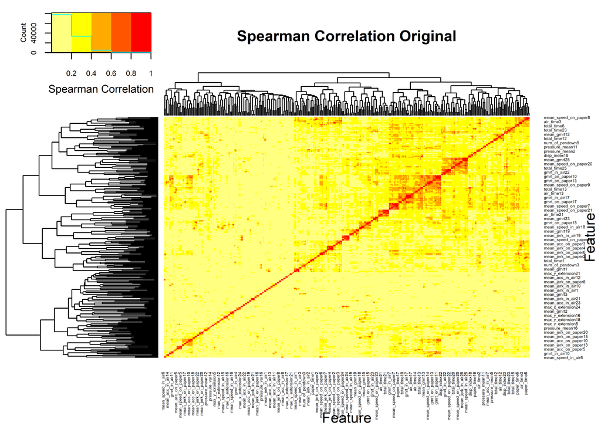

```r
par(cex=0.6,cex.main=0.85,cex.axis=0.7)
cormat <- cor(dataframe[,rownames(demat)],method="spearman")
cormat[is.na(cormat)] <- 0
gplots::heatmap.2(abs(cormat),
                  trace = "none",
#                  scale = "row",
                  mar = c(5,5),
                  col=rev(heat.colors(5)),
                  main = "Spearman Correlation Original",
                  cexRow = 0.35,
                  cexCol = 0.35,
                  key.title=NA,
                  key.xlab="Spearman Correlation",
                  xlab="Feature", ylab="Feature")
```

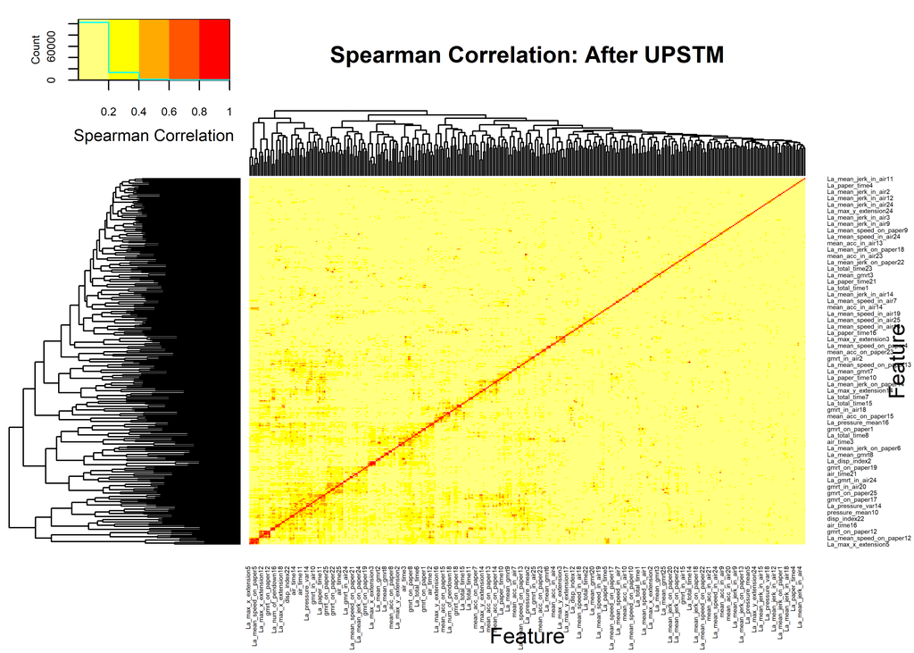

```r
cormat <- cor(DEdataframe[,colnames(demat)],method="spearman")
cormat[is.na(cormat)] <- 0
gplots::heatmap.2(abs(cormat),
                  trace = "none",
#                  scale = "none",
                  mar = c(5,5),
                  col=rev(heat.colors(5)),
                  main = "Spearman Correlation: After UPSTM",
                  cexRow = 0.35,
                  cexCol = 0.35,
                  key.title=NA,
                  key.xlab="Spearman Correlation",
                  xlab="Feature", ylab="Feature")
```

```r
par(op)
```

## 1.4 Univariate Decorrelated

```r
univarDe <- uniRankVar(varlistDe,
              paste(outcome,"~1"),
                outcome,
              DEdataframe,
                categorizationType = "Raw",
                type = "LOGIT",
                rankingTest = "AUC",
                cateGroups = c(0.1, 0.9),
                raw.dataFrame = NULL,
                description = ".",
                uniType = "Binary")
```

100 : La_mean_jerk_on_paper12 200 : La_mean_jerk_in_air23

```r
pander::pander(univarDe$orderframe[1:20,univariate_columns])
```

|  | caseMean | caseStd | controlMean | controlStd | controlKSP | ROCAUC | WilcoxRes.p | FRes.p |
| --- | --- | --- | --- | --- | --- | --- | --- | --- |
| **La_mean_speed_on_paper2** | -0.121 | 0.2097 | 0.00476 | 0.1552 | 6.60e-05 | 0.730 | 1.02e-06 | 2.32e-06 |
| **La_max_y_extension18** | 0.730 | 0.3972 | 0.48081 | 0.3343 | 7.18e-01 | 0.718 | 3.54e-07 | 8.87e-07 |
| **La_mean_speed_on_paper13** | -5.051 | 0.0680 | -5.01659 | 0.1066 | 2.18e-05 | 0.718 | 4.56e-07 | 3.50e-05 |
| **La_gmrt_on_paper2** | 1.022 | 0.7484 | 1.58133 | 0.6415 | 7.22e-01 | 0.715 | 7.20e-07 | 1.82e-07 |
| **La_max_x_extension12** | 1.066 | 0.4892 | 0.71610 | 0.3860 | 6.15e-01 | 0.711 | 6.43e-07 | 2.12e-07 |
| **La_mean_speed_on_paper12** | -0.259 | 0.1076 | -0.18925 | 0.1039 | 3.63e-01 | 0.710 | 8.43e-07 | 1.08e-06 |
| **La_pressure_mean2** | 0.033 | 0.2993 | 0.21729 | 0.1566 | 3.40e-02 | 0.710 | 7.70e-07 | 1.32e-07 |
| **La_mean_jerk_in_air7** | -5.710 | 0.0509 | -5.75623 | 0.0780 | 2.24e-01 | 0.705 | 9.64e-07 | 1.11e-06 |
| **La_num_of_pendown5** | 1.281 | 1.1665 | 0.50968 | 0.6873 | 4.18e-03 | 0.690 | 1.34e-06 | 1.41e-07 |
| **La_paper_time1** | 15.308 | 0.2236 | 15.18954 | 0.0995 | 4.47e-01 | 0.688 | 2.42e-06 | 9.12e-07 |
| **La_gmrt_on_paper3** | 0.470 | 0.7811 | 0.94292 | 0.7173 | 1.37e-01 | 0.682 | 2.22e-05 | 1.82e-05 |
| **La_mean_acc_on_paper21** | 45.781 | 0.1531 | 45.68635 | 0.1651 | 7.41e-01 | 0.681 | 1.53e-05 | 2.73e-05 |
| **La_mean_speed_on_paper16** | -0.112 | 0.2187 | 0.00486 | 0.1320 | 4.48e-01 | 0.681 | 9.41e-06 | 4.80e-06 |
| **La_mean_jerk_in_air17** | -8.793 | 0.0225 | -8.80587 | 0.0235 | 5.24e-01 | 0.679 | 2.51e-05 | 1.23e-04 |
| **La_mean_gmrt2** | 12.942 | 0.1863 | 13.09157 | 0.2694 | 4.54e-01 | 0.679 | 1.84e-05 | 7.99e-06 |
| **La_total_time8** | 18.192 | 0.3712 | 17.97170 | 0.3627 | 2.62e-01 | 0.677 | 4.22e-05 | 3.81e-05 |
| **La_mean_gmrt23** | 7.002 | 0.1575 | 7.06474 | 0.1141 | 5.35e-01 | 0.675 | 4.02e-05 | 5.60e-04 |
| **La_paper_time8** | 13.585 | 0.3682 | 13.39069 | 0.1987 | 2.31e-01 | 0.673 | 2.17e-05 | 1.12e-05 |
| **La_paper_time11** | 15.831 | 0.3412 | 15.65194 | 0.1090 | 6.07e-01 | 0.670 | 1.12e-05 | 7.27e-07 |
| **La_max_y_extension14** | 0.632 | 0.5486 | 0.29345 | 0.5885 | 1.43e-01 | 0.669 | 7.35e-05 | 4.93e-05 |

### 1.4.1 Comparing Decorrelation vs Original

```r
pthr <- 0.20/(ncol(dataframe)-1)

topDecorNames <- rownames(univarDe$orderframe[univarDe$orderframe$FRes.p<pthr,])
topDecorNames <- unique(c(topDecorNames,rownames(univarDe$orderframe[1:5,])))

#topDecorNames <- rownames(univarDe$orderframe[univarDe$orderframe$FRes.p<1.0e-5,])
dc <- getLatentCoefficients(DEdataframe)
### 2a Get only the ones that in the top features
deNames_in_dc <- topDecorNames[topDecorNames %in% names(dc)]
selectedlist <- dc[deNames_in_dc]
theDeFormulas <- selectedlist

rawuniv <- univariate_Wilcoxon(dataframe,outcome,limit=-1)
deuniv <- univariate_Wilcoxon(DEdataframe,outcome,limit=-1)
matsize <- (ncol(dataframe)-1)^2
nocorrelated <- ncol(dataframe) - 1 - ncol(demat)
pander::pander(c(sparse_Fraction=(sum(demat != 0) + nocorrelated)/matsize))
```

| sparse_Fraction |
| --- |
| 0.00348 |

```r
pander::pander(c(raw=length(rawuniv),decor=length(deuniv)))
```

| raw | decor |
| --- | --- |
| 364 | 296 |

```r
pander::pander(c(Number_Latent=length(dc)))
```

| Number_Latent |
| --- |
| 220 |

```r
pander::pander(c(meanSize=mean(sapply(dc,length))))
```

| meanSize |
| --- |
| 2.15 |

## 1.5 CV ROC Analysis

```r
par(op)
par(mfrow=c(1,2),cex=0.9)
fraction <-0.70
repetitions <- 100

fcout <- round(fraction*nrow(dataframe)/15+1.0)
pander::pander(c(NumberofFeatures=fcout))
```

| NumberofFeatures |
| --- |
| 9 |

```r
cvRaw <- randomCV(dataframe,
                outcome,
                fittingFunction= filteredFit,
                classSamplingType = "Pro",
                trainFraction = fraction,
                repetitions = repetitions,
#                fitmethod=  glm,
                fitmethod=  KNN_method,
                filtermethod=mRMR.classic_FRESA,
                filtermethod.control=list(feature_count= fcout),
#                family="binomial"
)
```

……….10 Tested: 169 Avg. Selected: 9 Min Tests: 1 Max Tests: 7 Mean Tests: 3.136095 . MAD: 0.2271872

……….20 Tested: 174 Avg. Selected: 9 Min Tests: 1 Max Tests: 12 Mean Tests: 6.091954 . MAD: 0.2140708

……….30 Tested: 174 Avg. Selected: 9 Min Tests: 4 Max Tests: 17 Mean Tests: 9.137931 . MAD: 0.2152471

……….40 Tested: 174 Avg. Selected: 9 Min Tests: 5 Max Tests: 19 Mean Tests: 12.18391 . MAD: 0.2191041

……….50 Tested: 174 Avg. Selected: 9 Min Tests: 7 Max Tests: 25 Mean Tests: 15.22989 . MAD: 0.2162808

……….60 Tested: 174 Avg. Selected: 9 Min Tests: 8 Max Tests: 30 Mean Tests: 18.27586 . MAD: 0.2152973

……….70 Tested: 174 Avg. Selected: 9 Min Tests: 11 Max Tests: 31 Mean Tests: 21.32184 . MAD: 0.2134381

……….80 Tested: 174 Avg. Selected: 9 Min Tests: 12 Max Tests: 34 Mean Tests: 24.36782 . MAD: 0.2143991

……….90 Tested: 174 Avg. Selected: 9 Min Tests: 14 Max Tests: 38 Mean Tests: 27.41379 . MAD: 0.2129045

……….100 Tested: 174 Avg. Selected: 9 Min Tests: 18 Max Tests: 43 Mean Tests: 30.45977 . MAD: 0.2122172

```r
bpraw <- predictionStats_binary(cvRaw$medianTest,"RAW",cex=0.75)
```

RAW

```r
pander::pander(bpraw$CM.analysis$tab)
```

|  | Outcome + | Outcome - | Total |
| --- | --- | --- | --- |
| **Test +** | 65 | 5 | 70 |
| **Test -** | 24 | 80 | 104 |
| **Total** | 89 | 85 | 174 |

```r
pander::pander(bpraw$accc)
```

| est | lower | upper |
| --- | --- | --- |
| 0.833 | 0.769 | 0.885 |

```r
pander::pander(bpraw$aucs)
```

| est | lower | upper |
| --- | --- | --- |
| 0.935 | 0.9 | 0.97 |

```r
pander::pander(bpraw$berror)
```

| 50% | 2.5% | 97.5% |
| --- | --- | --- |
| 0.163 | 0.117 | 0.217 |

```r
cvDe <- randomCV(DEdataframe,
                outcome,
                fittingFunction= filteredFit,
                trainSampleSets= cvRaw$trainSamplesSets,
#                fitmethod=  glm,
                fitmethod=  KNN_method,
                filtermethod=mRMR.classic_FRESA,
                filtermethod.control=list(feature_count= fcout),
#                family="binomial"
)
```

……….10 Tested: 169 Avg. Selected: 9 Min Tests: 1 Max Tests: 7 Mean Tests: 3.136095 . MAD: 0.248869

……….20 Tested: 174 Avg. Selected: 9 Min Tests: 1 Max Tests: 12 Mean Tests: 6.091954 . MAD: 0.2286479

……….30 Tested: 174 Avg. Selected: 9 Min Tests: 4 Max Tests: 17 Mean Tests: 9.137931 . MAD: 0.2246004

……….40 Tested: 174 Avg. Selected: 9 Min Tests: 5 Max Tests: 19 Mean Tests: 12.18391 . MAD: 0.2329911

……….50 Tested: 174 Avg. Selected: 9 Min Tests: 7 Max Tests: 25 Mean Tests: 15.22989 . MAD: 0.2333257

……….60 Tested: 174 Avg. Selected: 9 Min Tests: 8 Max Tests: 30 Mean Tests: 18.27586 . MAD: 0.2361974

……….70 Tested: 174 Avg. Selected: 9 Min Tests: 11 Max Tests: 31 Mean Tests: 21.32184 . MAD: 0.2330593

……….80 Tested: 174 Avg. Selected: 9 Min Tests: 12 Max Tests: 34 Mean Tests: 24.36782 . MAD: 0.2312259

……….90 Tested: 174 Avg. Selected: 9 Min Tests: 14 Max Tests: 38 Mean Tests: 27.41379 . MAD: 0.2299843

……….100 Tested: 174 Avg. Selected: 9 Min Tests: 18 Max Tests: 43 Mean Tests: 30.45977 . MAD: 0.2281858

```r
bpDecor <- predictionStats_binary(cvDe$medianTest,"Decorrelated",cex=0.75)
```

Decorrelated

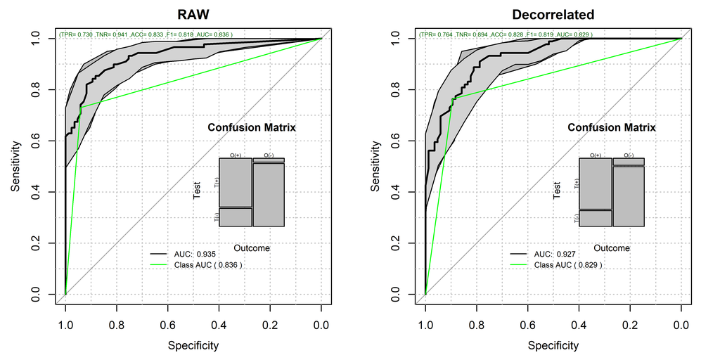

```r
par(op)

pander::pander(bpDecor$CM.analysis$tab)
```

|  | Outcome + | Outcome - | Total |
| --- | --- | --- | --- |
| **Test +** | 68 | 9 | 77 |
| **Test -** | 21 | 76 | 97 |
| **Total** | 89 | 85 | 174 |

```r
pander::pander(bpDecor$accc)
```

| est | lower | upper |
| --- | --- | --- |
| 0.828 | 0.763 | 0.881 |

```r
pander::pander(bpDecor$aucs)
```

| est | lower | upper |
| --- | --- | --- |
| 0.927 | 0.891 | 0.962 |

```r
pander::pander(bpDecor$berror)
```

| 50% | 2.5% | 97.5% |
| --- | --- | --- |
| 0.171 | 0.114 | 0.22 |

```r
### Here we compute the probability that the outcome-driven decorrelation ROC is superior to the RAW ROC.
pander::pander(roc.test(bpDecor$ROC.analysis$roc.predictor,bpraw$ROC.analysis$roc.predictor,alternative = "greater"))
```

DeLong’s test for two correlated ROC curves: `bpDecor$ROC.analysis$roc.predictor` and `bpraw$ROC.analysis$roc.predictor`

| Test statistic | P value | Alternative hypothesis | AUC of roc1 | AUC of roc2 |
| --- | --- | --- | --- | --- |
| -0.975 | 0.835 | greater | 0.927 | 0.935 |

## 1.6 Feature Frequency Plots

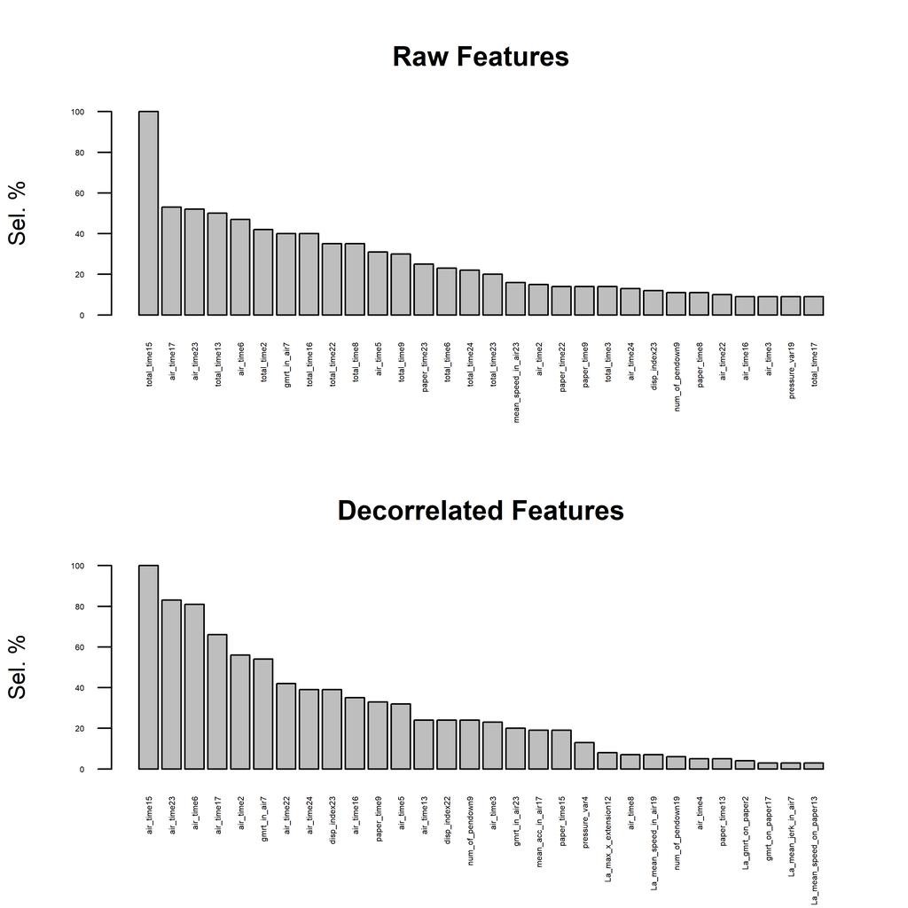

```r
par(mfrow=c(2,1),cex=0.9,cex.axis=0.8)

rawtopf <- cvRaw$featureFrequency/repetitions
crawtopf <- rawtopf

if (length(rawtopf) > 30)
{
  rawtopf <- rawtopf[1:30]
}
barplot(100*rawtopf,las=2,main="Raw Features",ylim=c(0,100.0),cex.names = 0.35,cex.axis = 0.35,ylab="Sel. %")

detopf <- cvDe$featureFrequency/repetitions
cdetopf <- detopf
names(cdetopf) <- str_remove_all(names(cdetopf),"Ba_")
names(cdetopf) <- str_remove_all(names(cdetopf),"La_")
if (length(detopf) > 30)
{
  detopf <- detopf[1:30]
}

barplot(100*detopf,las=2,main="Decorrelated Features",ylim=c(0,100.0),cex.names = 0.35,cex.axis = 0.35,ylab="Sel. %")
```

```r
par(op)
```

### 1.6.1 Final Table

```r
unlistdecorr <- selectedlist
names(unlistdecorr) <- NULL
unlistdecorr <- unique(names(unlist(unlistdecorr)))

finalTableDe <- univarDe$orderframe[deNames_in_dc,univariate_columns]

finalTableOr <- univar$orderframe[unique(c(topfiveOrg,unlistdecorr,names(crawtopf)[1:2],names(cdetopf)[1:2])),univariate_columns]

finalTable <- rbind(finalTableOr,finalTableDe)

deFromula <- character(length(theDeFormulas))
names(deFromula) <- names(theDeFormulas)

for (dx in names(deFromula))
{
  coef <- theDeFormulas[[dx]]
  cname <- names(theDeFormulas[[dx]])
  names(cname) <- cname
  for (cf in names(coef))
  {
    if (cf != dx)
    {
      if (coef[cf]>0)
      {
        deFromula[dx] <- paste(deFromula[dx],
                               sprintf("+ %5.3f*%s",coef[cf],cname[cf]))
      }
      else
      {
        deFromula[dx] <- paste(deFromula[dx],
                               sprintf("%5.3f*%s",coef[cf],cname[cf]))
      }
    }
  }
}
orgnamez <- rownames(finalTable)
orgnamez <- str_remove_all(orgnamez,"Ba_")
orgnamez <- str_remove_all(orgnamez,"La_")
finalTable$uAUC <- univar$orderframe[orgnamez,"ROCAUC"]
finalTable$raw_Freq <- crawtopf[orgnamez]
finalTable$La_Freq <- cdetopf[orgnamez]
finalTable$DecorFormula <- deFromula[rownames(finalTable)]
fscores <- attr(DEdataframe,"fscore")
finalTable$fscores <- fscores[rownames(finalTable)]

finalTable <- finalTable[order(-finalTable$ROCAUC),]

pander::pander(finalTable)
```

|  | caseMean | caseStd | controlMean | controlStd | controlKSP | ROCAUC | WilcoxRes.p | FRes.p | uAUC | raw_Freq | La_Freq | DecorFormula | fscores |
| --- | --- | --- | --- | --- | --- | --- | --- | --- | --- | --- | --- | --- | --- |
| **total_time23** | 37.2307 | 0.5026 | 36.66576 | 0.4844 | 1.03e-05 | 0.863 | 1.80e-16 | 0.00e+00 | 0.863 | 0.20 | NA | NA | NA |
| **total_time15** | 38.0918 | 0.8748 | 37.14648 | 0.4208 | 5.44e-01 | 0.844 | 1.09e-15 | 0.00e+00 | 0.844 | 1.00 | NA | NA | NA |
| **air_time23** | 36.6116 | 0.6260 | 35.85799 | 0.6555 | 6.92e-03 | 0.844 | 3.11e-15 | 0.00e+00 | 0.844 | 0.52 | 0.83 | NA | 1 |
| **air_time15** | 37.7203 | 1.0939 | 36.60743 | 0.6151 | 5.06e-01 | 0.829 | 1.42e-14 | 5.55e-17 | 0.829 | NA | 1.00 | NA | 1 |
| **total_time17** | 38.5262 | 0.6813 | 37.84811 | 0.6137 | 4.00e-03 | 0.824 | 1.08e-13 | 2.00e-15 | 0.824 | 0.09 | NA | NA | NA |
| **air_time17** | 37.9116 | 0.9139 | 37.00002 | 0.7952 | 3.52e-02 | 0.806 | 5.16e-13 | 1.67e-14 | 0.806 | 0.53 | 0.66 | NA | 1 |
| **total_time8** | 36.7275 | 0.8047 | 35.99881 | 0.5135 | 4.89e-01 | 0.776 | 1.04e-10 | 4.31e-12 | 0.776 | 0.35 | NA | NA | NA |
| **paper_time10** | 35.9210 | 0.5539 | 35.46434 | 0.3186 | 5.22e-01 | 0.768 | 1.36e-09 | 7.39e-11 | 0.768 | 0.05 | NA | NA | NA |
| **mean_acc_in_air17** | 27.6279 | 0.5699 | 28.13361 | 0.5343 | 1.82e-01 | 0.767 | 4.79e-10 | 2.14e-10 | 0.767 | 0.04 | 0.19 | NA | 2 |
| **mean_jerk_in_air17** | 25.9283 | 0.6215 | 26.46259 | 0.5993 | 7.59e-02 | 0.766 | 5.62e-10 | 3.63e-10 | 0.766 | 0.01 | NA | NA | NA |
| **paper_time8** | 36.1753 | 0.6646 | 35.60158 | 0.4409 | 6.77e-01 | 0.763 | 1.07e-09 | 6.83e-11 | 0.763 | 0.11 | NA | NA | NA |
| **paper_time11** | 35.8463 | 0.5598 | 35.46553 | 0.3115 | 2.38e-01 | 0.753 | 1.70e-08 | 3.60e-09 | 0.753 | NA | NA | NA | NA |
| **total_time10** | 36.5808 | 0.7936 | 35.95132 | 0.4304 | 9.17e-01 | 0.743 | 9.69e-09 | 4.66e-10 | 0.743 | NA | 0.01 | NA | NA |
| **La_mean_speed_on_paper2** | -0.1210 | 0.2097 | 0.00476 | 0.1552 | 6.60e-05 | 0.730 | 1.02e-06 | 2.32e-06 | 0.720 | NA | NA | -0.876*gmrt_on_paper2 + 1.000*mean_speed_on_paper2 | -1 |
| **mean_speed_on_paper2** | 27.8133 | 0.4917 | 27.88786 | 3.0908 | 5.50e-13 | 0.720 | 1.06e-06 | 4.01e-01 | 0.720 | NA | NA | NA | NA |
| **La_max_y_extension18** | 0.7304 | 0.3972 | 0.48081 | 0.3343 | 7.18e-01 | 0.718 | 3.54e-07 | 8.87e-07 | 0.466 | NA | 0.02 | -1.070*gmrt_on_paper18 + 1.000*max_y_extension18 | -1 |
| **La_mean_speed_on_paper13** | -5.0507 | 0.0680 | -5.01659 | 0.1066 | 2.18e-05 | 0.718 | 4.56e-07 | 3.50e-05 | 0.626 | NA | 0.03 | -1.035*gmrt_on_paper13 + 1.000*mean_speed_on_paper13 | -1 |
| **La_gmrt_on_paper2** | 1.0222 | 0.7484 | 1.58133 | 0.6415 | 7.22e-01 | 0.715 | 7.20e-07 | 1.82e-07 | 0.337 | NA | 0.04 | + 1.000*gmrt_on_paper2 -1.226*mean_acc_on_paper2 | 0 |
| **La_max_x_extension12** | 1.0656 | 0.4892 | 0.71610 | 0.3860 | 6.15e-01 | 0.711 | 6.43e-07 | 2.12e-07 | 0.447 | NA | 0.08 | -1.034*gmrt_on_paper12 + 1.000*max_x_extension12 | -1 |
| **air_time8** | 35.5206 | 1.3209 | 34.54674 | 1.0223 | 2.63e-01 | 0.710 | 4.26e-07 | 1.28e-07 | 0.710 | NA | 0.07 | NA | 1 |
| **La_mean_speed_on_paper12** | -0.2591 | 0.1076 | -0.18925 | 0.1039 | 3.63e-01 | 0.710 | 8.43e-07 | 1.08e-06 | 0.658 | NA | NA | -0.887*gmrt_on_paper12 + 1.000*mean_speed_on_paper12 | -1 |
| **La_pressure_mean2** | 0.0330 | 0.2993 | 0.21729 | 0.1566 | 3.40e-02 | 0.710 | 7.70e-07 | 1.32e-07 | 0.312 | NA | NA | -1.025*max_y_extension2 + 0.083*mean_acc_on_paper2 + 1.000*pressure_mean2 | -2 |
| **mean_speed_on_paper15** | 28.2597 | 0.5802 | 28.66196 | 0.4184 | 7.07e-01 | 0.705 | 1.20e-06 | 2.65e-07 | 0.705 | NA | NA | NA | NA |
| **La_mean_jerk_in_air7** | -5.7100 | 0.0509 | -5.75623 | 0.0780 | 2.24e-01 | 0.705 | 9.64e-07 | 1.11e-06 | 0.695 | NA | 0.03 | -1.145*mean_acc_in_air7 + 1.000*mean_jerk_in_air7 | -1 |
| **mean_speed_on_paper9** | 28.3106 | 0.6697 | 28.72207 | 0.4517 | 3.39e-01 | 0.703 | 1.49e-06 | 1.15e-06 | 0.703 | NA | NA | NA | NA |
| **disp_index10** | 15.6648 | 0.2649 | 15.47184 | 0.2594 | 7.58e-01 | 0.700 | 2.49e-06 | 1.13e-06 | 0.700 | NA | NA | NA | 1 |
| **mean_jerk_in_air7** | 25.5852 | 0.7092 | 26.02676 | 0.9451 | 5.23e-02 | 0.695 | 1.23e-05 | 1.19e-04 | 0.695 | NA | 0.03 | NA | NA |
| **disp_index11** | 15.6120 | 0.3706 | 15.45481 | 0.2372 | 4.54e-01 | 0.695 | 7.17e-06 | 2.19e-05 | 0.695 | NA | NA | NA | 1 |
| **mean_acc_in_air7** | 27.3302 | 0.6168 | 27.75625 | 0.8124 | 1.61e-01 | 0.695 | 9.10e-06 | 2.86e-05 | 0.695 | NA | NA | NA | 1 |
| **mean_jerk_in_air2** | 24.7836 | 0.7192 | 24.30683 | 0.6425 | 2.03e-02 | 0.694 | 5.80e-06 | 2.49e-06 | 0.694 | NA | NA | NA | NA |

[output cut: 88 more lines]